#### Author: Miguel Jácome-Flores

# *Chamaerops humilis* Bipartite Networks analysis

## *Frugivores visits*

#### **Step 1.** Analysis of the aggregation area of each dwarf palm through *Dirilichet tesselations* . We use the coordinate of both males and females to obtain a proxy of aggregation.

```
library(deldir)
```

```
martcoord<-read.csv("~/Desktop/Palmito/Postdoc-Interaction Networks/Dispersal-Networks/Coordinates/BufferSelectionMartinazo.csv", header=TRUE)
deldir(martcoord)

matascoord<-read.csv("~/Desktop/Palmito/Postdoc-Interaction Networks/Dispersal-Networks/Coordinates/BufferselectionMatasgordas.csv", header=TRUE)
deldir(matascoord)
```

From the summary of the obtained data.frame we use the *del.area* that use the information of all the neighbourhood and the nn to create triangular areas. It corrects using 1/3 of the total area of all the Delaunay triangles emanating from the point.The results were use to order the plants from “less to more aggegated” for a better visualization of the effect of this variable.

#### **Step 2.** Open Martinazo and Matasgordas matrix

Opening a matrix file with weighted visits of frugivores in individual plants, the “row.names=1” is necessary to run the model and to detect the “name of plants” in the matrix. *Note: visit frequency= animal-visit-days/total-survey days.*

```r
#Martinazo
mart<-read.csv("~/Desktop/Palmito/Postdoc-Interaction Networks/mart_visit.csv",header=TRUE,check.names=FALSE,row.names=1)

#Matasgordas
matas<-read.csv("~/Desktop/Palmito/Postdoc-Interaction Networks/matas_visit.csv",header=TRUE,check.names=FALSE,row.names=1)
```

#### **Step 3.** Using “bipartite” package. This package have functions to represent bipartite networks, and to obtain different indexes to describe the topology of the network.

```
library(bipartite)
```

##### *Step 3.1.* Ploting the web.

Creates a bipartite network were the high level will be represented by the frugivores and low level to each individual plant. Plants arrengement represents the aggregation level from high-low aggregation. This was obtained through *Dirilichet tesselations*, where plants highly aggregated were those with the less area without any other dwarf palm. [^1]

There is an evident change on the interactions (visits/day/animal) made by deers and wildboars with a decrease in Matasgordas (second panel). Also, there is an increase of rodents, rabbits and unknown visitors (maybe be rats?)

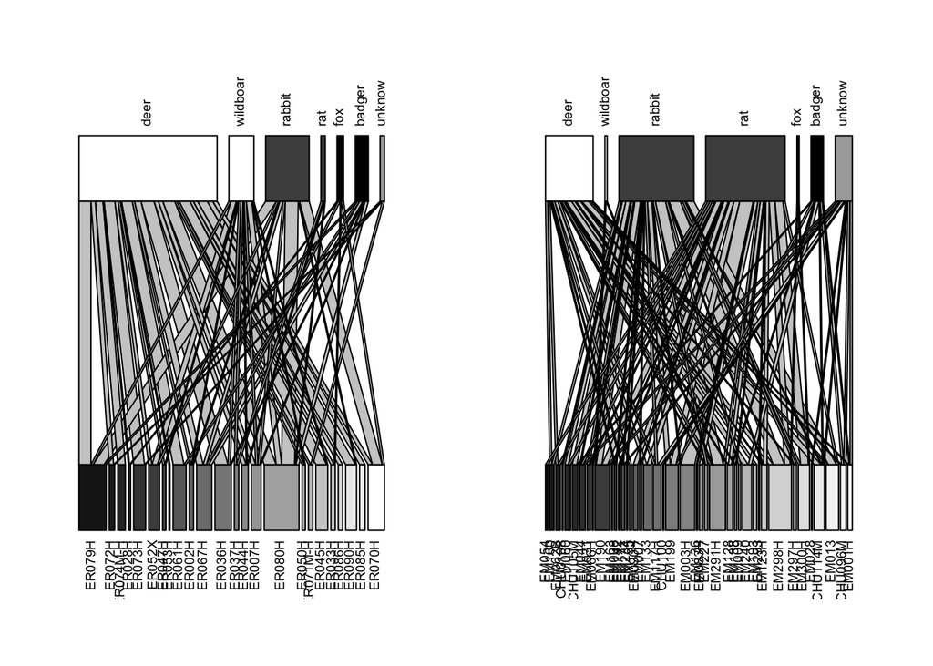

Figure 2. The first figure represent the Martinazo network and the second Matasgordas.Plants colors in gray scale [col.low=c(gray(seq(0.1,1,length=24)))], goes from black (aggregated plants) to white (more isolated), *length* refers to the number of plants in the plot. In High level, different colors in “col.high” means different guilds: white=predators, dark gray=defleshers, black=dispersers and light gray=unknow."

#### **Step 4.** Calculate indices describing network topography of the general network.

The reults are useful to describe the changes in different networks

##### **Step 4.1.** Network measures

```r
#Martinazo
networklevel(mart, index = c("connectance","web asymmetry","cluster coefficient","nestedness","weighted nestedness"))
```

```
##            connectance          web asymmetry    cluster coefficient
##              0.3452381             -0.5483871              0.2500000
##             nestedness    weighted nestedness cluster.coefficient.HL
##             26.9572112              0.6220294              0.6971492
## cluster.coefficient.LL
##              0.4345642
```

```r
#Matasgordas
networklevel(matas,index = c("connectance","web asymmetry","cluster coefficient","nestedness","weighted nestedness"))
```

```
##            connectance          web asymmetry    cluster coefficient
##              0.2959184             -0.7142857              0.2142857
##             nestedness    weighted nestedness cluster.coefficient.HL
##             24.1104627              0.5713648              0.4869864
## cluster.coefficient.LL
##              0.3908290
```

- *Modularity:* Identify modules of closely interecting frugivores. Also test to what extent these modules have a spatial component. High modularity values means that the network is more stable.

Martinazo

```
## [1] 0.2844989
```

Matasgordas

```
## [1] 0.3746966
```

##### Ploting modules in the networks

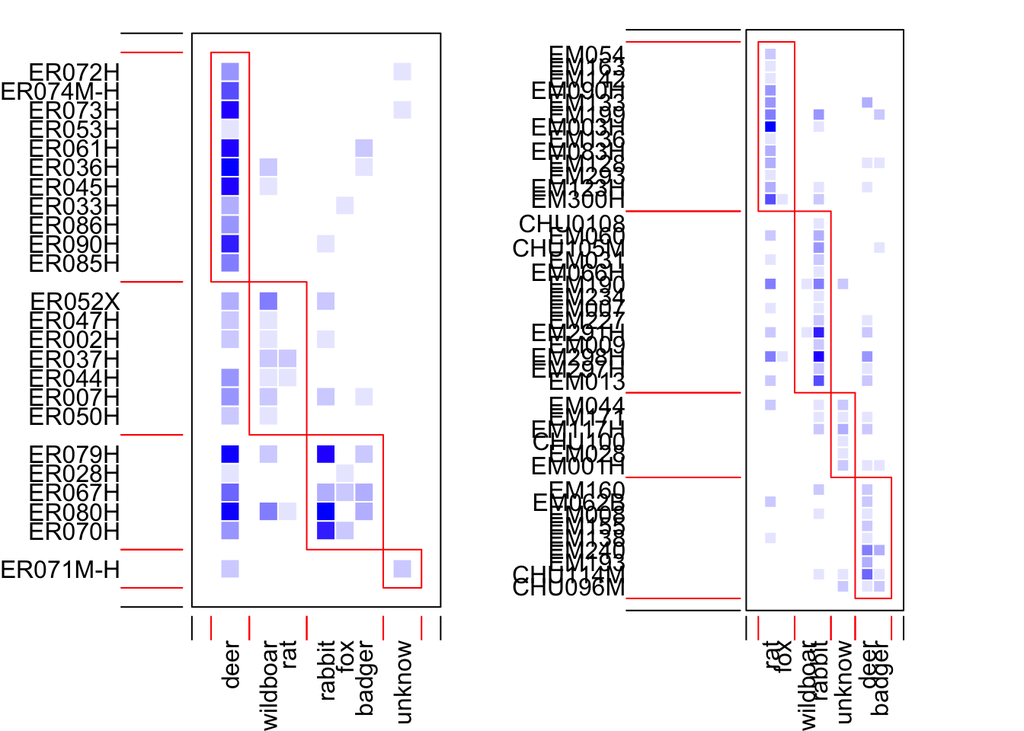

Figure 3.

There is a change in the visitation modules. Perhaps the module in Martinazo composed by fox, rabbit and badger is related to an interactiion between animals. Both carnivorous (fox and badger) not only visit plant because of the “fruit resource” both also for the “rabbits resource”. However we can rule this pattern because in Matasgordas the badger is wtihin a module with deer. Instead, it appears that the “unknwon visitors” in both populations creates their own module.

&nbsp * **Link level.** Interaction variance between nodes. The outcome is a matrix with dependence values. Computes the contribution of each species to the overall nestedness.

```r
linklevel(mart)
```

```
## $`HL dependence`
##                 deer   wildboar     rabbit       rat   fox badger
## ER079H   0.086656587 0.08711528 0.24992499 0.0000000 0.000  0.167
## ER072H   0.031468531 0.00000000 0.00000000 0.0000000 0.000  0.000
## ER074M-H 0.055093555 0.00000000 0.00000000 0.0000000 0.000  0.000
## ER028H   0.007843508 0.00000000 0.00000000 0.0000000 0.166  0.000
## ER073H   0.078718579 0.00000000 0.00000000 0.0000000 0.000  0.000
## ER052X   0.023625024 0.21752739 0.05010501 0.0000000 0.000  0.000
## ER047H   0.015781516 0.04329682 0.00000000 0.0000000 0.000  0.000
## ER053H   0.007843508 0.00000000 0.00000000 0.0000000 0.000  0.000
## ER061H   0.078718579 0.00000000 0.00000000 0.0000000 0.000  0.167
## ER002H   0.015781516 0.04329682 0.02490249 0.0000000 0.000  0.000
## ER067H   0.047250047 0.00000000 0.07500750 0.0000000 0.334  0.250
## ER036H   0.094500095 0.08711528 0.00000000 0.0000000 0.000  0.083
## ER037H   0.000000000 0.08711528 0.00000000 0.5015015 0.000  0.000
## ER044H   0.031468531 0.04329682 0.00000000 0.2492492 0.000  0.000
## ER007H   0.031468531 0.08711528 0.05010501 0.0000000 0.000  0.083
## ER080H   0.086656587 0.21752739 0.30003000 0.2492492 0.000  0.250
## ER050H   0.015781516 0.04329682 0.00000000 0.0000000 0.000  0.000
## ER071M-H 0.015781516 0.00000000 0.00000000 0.0000000 0.000  0.000
## ER045H   0.078718579 0.04329682 0.00000000 0.0000000 0.000  0.000
## ER033H   0.023625024 0.00000000 0.00000000 0.0000000 0.166  0.000
## ER086H   0.031468531 0.00000000 0.00000000 0.0000000 0.000  0.000
## ER090H   0.070875071 0.00000000 0.02490249 0.0000000 0.000  0.000
## ER085H   0.039406539 0.00000000 0.00000000 0.0000000 0.000  0.000
## ER070H   0.031468531 0.00000000 0.22502250 0.0000000 0.334  0.000
##             unknow
## ER079H   0.0000000
## ER072H   0.2492492
## ER074M-H 0.0000000
## ER028H   0.0000000
## ER073H   0.2492492
## ER052X   0.0000000
## ER047H   0.0000000
## ER053H   0.0000000
## ER061H   0.0000000
## ER002H   0.0000000
## ER067H   0.0000000
## ER036H   0.0000000
## ER037H   0.0000000
```

[output cut: 75 more lines]

```
## ER002H     69       33     24   0   0      0      0
## ER067H     92        0     32   0  16     24      0
## ER036H     69       33      0   0   0     18      0
## ER037H      0       22      0   6   0      0      0
## ER044H     69       33      0   9   0      0      0
## ER007H     92       44     32   0   0     24      0
## ER080H    115       55     40  15   0     30      0
## ER050H     46       22      0   0   0      0      0
## ER071M-H   46        0      0   0   0      0      6
## ER045H     46       22      0   0   0      0      0
## ER033H     46        0      0   0   8      0      0
## ER086H     23        0      0   0   0      0      0
## ER090H     46        0     16   0   0      0      0
## ER085H     23        0      0   0   0      0      0
## ER070H     69        0     24   0  12      0      0
```

```r
linklevel(matas)
```

```
## $`HL dependence`
##               deer wildboar     rabbit        rat fox     badger unknow
## EM054   0.00000000      0.0 0.00000000 0.02863021 0.0 0.00000000 0.0000
## EM160   0.04772792      0.0 0.03037468 0.00000000 0.0 0.00000000 0.0000
## EM236   0.00000000      0.0 0.00000000 0.00000000 0.0 0.00000000 0.0000
## EM062B  0.04772792      0.0 0.00000000 0.02863021 0.0 0.00000000 0.0000
## CHU0108 0.00000000      0.0 0.01509640 0.00000000 0.0 0.00000000 0.0000
## EM060   0.00000000      0.0 0.04547108 0.02863021 0.0 0.00000000 0.0000
## CHU105M 0.00000000      0.0 0.06056748 0.00000000 0.0 0.09061135 0.0000
## EM044   0.00000000      0.0 0.01509640 0.02863021 0.0 0.00000000 0.1336
## EM031   0.00000000      0.0 0.03037468 0.01422938 0.0 0.00000000 0.0000
## EM066H  0.00000000      0.0 0.01509640 0.00000000 0.0 0.00000000 0.0000
## EM190   0.00000000      0.5 0.07584576 0.07148980 0.0 0.00000000 0.1336
## EM163   0.00000000      0.0 0.00000000 0.01422938 0.0 0.00000000 0.0000
## EM008   0.02372106      0.0 0.01509640 0.00000000 0.0 0.00000000 0.0000
## EM142   0.00000000      0.0 0.00000000 0.01422938 0.0 0.00000000 0.0000
## EM171   0.02372106      0.0 0.01509640 0.00000000 0.0 0.00000000 0.0664
## EM234   0.00000000      0.0 0.01509640 0.00000000 0.0 0.00000000 0.0000
## EM270   0.00000000      0.0 0.00000000 0.00000000 0.0 0.00000000 0.0000
## EM155   0.04772792      0.0 0.00000000 0.00000000 0.0 0.00000000 0.0000
## EM090H  0.00000000      0.0 0.00000000 0.05708898 0.0 0.00000000 0.0000
## EM007   0.00000000      0.0 0.01509640 0.01422938 0.0 0.00000000 0.0000
## EM097H  0.00000000      0.0 0.00000000 0.00000000 0.0 0.00000000 0.0000
## EM133   0.07144899      0.0 0.00000000 0.05708898 0.0 0.00000000 0.0000
## EM117H  0.04772792      0.0 0.03037468 0.00000000 0.0 0.00000000 0.2000
## CHU100  0.00000000      0.0 0.00000000 0.00000000 0.0 0.00000000 0.0664
## EM199   0.00000000      0.0 0.06056748 0.07148980 0.0 0.18231441 0.0000
## EM003H  0.00000000      0.0 0.01509640 0.17143837 0.0 0.00000000 0.0000
## EM136   0.00000000      0.0 0.00000000 0.01422938 0.0 0.00000000 0.0000
## EM083H  0.00000000      0.0 0.00000000 0.04285959 0.0 0.00000000 0.0000
## EM227   0.02372106      0.0 0.03037468 0.00000000 0.0 0.00000000 0.0000
## EM291H  0.04772792      0.5 0.13641324 0.02863021 0.0 0.00000000 0.0000
## CHU0111 0.00000000      0.0 0.00000000 0.00000000 0.0 0.00000000 0.0000
## EM128   0.02372106      0.0 0.00000000 0.04285959 0.0 0.09061135 0.0000
## EM138   0.02372106      0.0 0.00000000 0.01422938 0.0 0.00000000 0.0000
## EM009   0.00000000      0.0 0.03037468 0.00000000 0.0 0.00000000 0.0000
## EM240   0.11917691      0.0 0.00000000 0.00000000 0.0 0.27292576 0.0000
## EM193   0.07144899      0.0 0.00000000 0.00000000 0.0 0.00000000 0.0000
## EM293   0.00000000      0.0 0.00000000 0.01422938 0.0 0.00000000 0.0000
## EM123H  0.02372106      0.0 0.01509640 0.04285959 0.0 0.00000000 0.0000
```

[output cut: 138 more lines]

```
## EM128     60        0      0  69   0     21      0
## EM138     40        0      0  46   0      0      0
## EM009      0        0     24   0   0      0      0
## EM240     40        0      0   0   0     14      0
## EM193     20        0      0   0   0      0      0
## EM293      0        0      0  23   0      0      0
## EM123H    60        0     72  69   0      0      0
## EM298H    80        0     96  92   8      0      0
## EM297H    40        0     48   0   0      0      0
## EM300H     0        0     72  69   6      0      0
## EM028      0        0      0   0   0      0      9
## CHU114M   80        0     96   0   0     28     36
## EM013     60        0     72  69   0      0      0
## CHU096M   60        0      0   0   0     21     27
## EM001H    60        0      0   0   0     21     27
```

##### **Step 5.**Calculate the topography of the nodes and their relative importance to the network. Information that we can relate to the aggregation level of this plants through GLM or GAM.

There are three different levels this can be achieved at: the entire web (using function networklevel), at the level of each group (also using function networklevel) or the individual species (using function specieslevel).

- **Relative degree.** It is a centrality measure. Proportion of interactions in relation to the potential partners in the network. Importance with the number of plants or animals with which they interact. High values in individual plants in our system is related to “more attractiveness”. (qualitative characteristic of the node) interact or not
- **Species strength.** (Dorman, 2011). Describe how much the plants depends on the visits by a particular animal. Importance of the **plant** given by the porportion of visits of each animal. Instead, the values for **animals** tell us the importance of each animal given the proportion of visits that they made.
- **Species Specificity.** Coefficient of variation of interactions, normalised to values between 0 and 1. Values of 0 indicate low, those of 1 a high variability (and hence suggesting low and high specificity). We can determine if certain **plants** have high visitation of animals or low. Instead, for **animals** we can determine if they have a high visitation or low. (quantitative index). The difference in this index is that uses the visitation values of each interaction.
- **Node specialisation index.** Another measure of specialisation, based on the path length between any two higher-trophic level species. For instance, species sharing hosts/prey have an FS-value of 1. It is a purely qualitative measure. Smaller the values, the more directly type A species are linked with type B species in network, and the less strict is the functional specialization.level of interdependence between plant and frugivore species.
- **Effective partners.** The effective number of partners, if each partner was equally common. In our study is only useful for plants.

```
spp_lev_mart<-specieslevel(mart)
spp_lev_mart<-specieslevel(matas)
```

#### Martinazo

```r
HLspplvlmart<-specieslevel(mart)
HLspplvlmart$`higher level`[,c(2,3,8,10)]
```

```
##          normalised.degree species.strength species.specificity.index
## deer             0.9583333       15.6306655                 0.1441126
## wildboar         0.4583333        2.7629497                 0.3110135
## rabbit           0.3333333        2.3606853                 0.4252914
## rat              0.1250000        0.6974538                 0.5904346
## fox              0.1666667        1.0259512                 0.4968324
## badger           0.2500000        0.7321638                 0.3994204
## unknow           0.1250000        0.7901306                 0.5904346
##          node.specialisation.index.NSI
## deer                          1.000000
## wildboar                      1.333333
## rabbit                        1.166667
## rat                           1.333333
## fox                           1.500000
## badger                        1.166667
## unknow                        1.833333
```

```r
LLspplvlmart<-specieslevel(mart)
LLspplvlmart$`lower level`[,c(2,3,7,10,17)]
```

```
##          normalised.degree species.strength species.specificity.index
## ER079H           0.5714286      0.590696863                 0.5104912
## ER072H           0.2857143      0.280717781                 0.7920482
## ER074M-H         0.1428571      0.055093555                 1.0000000
## ER028H           0.2857143      0.173843508                 0.6454972
## ER073H           0.2857143      0.327967828                 0.8987386
## ER052X           0.4285714      0.291257421                 0.5259381
## ER047H           0.2857143      0.059078334                 0.6946385
## ER053H           0.1428571      0.007843508                 1.0000000
## ER061H           0.2857143      0.245718579                 0.8218319
## ER002H           0.4285714      0.083980824                 0.5212611
## ER067H           0.5714286      0.706257548                 0.4224565
## ER036H           0.4285714      0.264615379                 0.7784392
## ER037H           0.2857143      0.588616786                 0.6454972
## ER044H           0.4285714      0.324014599                 0.6461012
## ER007H           0.5714286      0.251688826                 0.4396605
## ER080H           0.7142857      1.103463225                 0.4185469
## ER050H           0.2857143      0.059078334                 0.6946385
## ER071M-H         0.2857143      0.517283017                 0.6454972
## ER045H           0.2857143      0.122015397                 0.8987386
## ER033H           0.2857143      0.189625024                 0.7505846
## ER086H           0.1428571      0.031468531                 1.0000000
## ER090H           0.2857143      0.095777561                 0.8891977
## ER085H           0.1428571      0.039406539                 1.0000000
## ER070H           0.4285714      0.590491034                 0.5974565
##          node.specialisation.index.NSI effective.partners
## ER079H                        1.000000           3.102768
## ER072H                        1.043478           1.648285
## ER074M-H                      1.043478           1.000000
## ER028H                        1.043478           2.000000
## ER073H                        1.043478           1.355201
## ER052X                        1.000000           2.800366
## ER047H                        1.000000           1.888128
## ER053H                        1.043478           1.000000
## ER061H                        1.043478           1.570034
## ER002H                        1.000000           2.825472
## ER067H                        1.043478           3.674766
## ER036H                        1.000000           1.872959
## ER037H                        1.565217           2.000000
## ER044H                        1.000000           2.378895
## ER007H                        1.000000           3.571645
## ER080H                        1.000000           3.876422
## ER050H                        1.000000           1.888128
## ER071M-H                      1.043478           2.000000
## ER045H                        1.000000           1.355201
## ER033H                        1.043478           1.753316
## ER086H                        1.043478           1.000000
## ER090H                        1.043478           1.383050
## ER085H                        1.043478           1.000000
## ER070H                        1.043478           2.528944
```

#### Matasgordas

```
##          normalised.degree species.strength species.specificity.index
## deer            0.47619048        8.3772788                 0.2236139
## wildboar        0.04761905        0.1476908                 0.6984303
## rabbit          0.57142857       12.8360563                 0.2327721
## rat             0.54761905       14.4442546                 0.2246552
## fox             0.04761905        0.1494598                 0.6984303
## badger          0.16666667        1.7165099                 0.3919900
## unknow          0.21428571        4.3287497                 0.3283117
##          node.specialisation.index.NSI
## deer                          1.000000
## wildboar                      1.333333
## rabbit                        1.000000
## rat                           1.000000
## fox                           1.500000
## badger                        1.333333
## unknow                        1.166667
```

```
##         normalised.degree species.strength species.specificity.index
## EM054           0.1428571       0.02863021                 1.0000000
## EM160           0.2857143       0.07810260                 0.6454972
## EM062B          0.2857143       0.07635813                 0.6454972
## CHU0108         0.1428571       0.01509640                 1.0000000
## EM060           0.2857143       0.07410129                 0.6631566
## CHU105M         0.2857143       0.15117883                 0.7920482
## EM044           0.4285714       0.17732661                 0.5037684
## EM031           0.2857143       0.04460407                 0.6946385
## EM066H          0.1428571       0.01509640                 1.0000000
## EM190           0.5714286       0.78093556                 0.4616904
## EM163           0.1428571       0.01422938                 1.0000000
## EM008           0.2857143       0.03881746                 0.6454972
## EM142           0.1428571       0.01422938                 1.0000000
## EM171           0.4285714       0.10521746                 0.4714045
## EM234           0.1428571       0.01509640                 1.0000000
## EM155           0.1428571       0.04772792                 1.0000000
## EM090H          0.1428571       0.05708898                 1.0000000
## EM007           0.2857143       0.02932578                 0.6454972
## EM133           0.2857143       0.12853796                 0.6545914
## EM117H          0.4285714       0.27810260                 0.4877833
## CHU100          0.1428571       0.06640000                 1.0000000
## EM199           0.4285714       0.31437169                 0.5168500
## EM003H          0.2857143       0.18653477                 0.9137180
## EM136           0.1428571       0.01422938                 1.0000000
## EM083H          0.1428571       0.04285959                 1.0000000
## EM227           0.2857143       0.05409574                 0.6946385
## EM291H          0.5714286       0.71277137                 0.6073588
## EM128           0.4285714       0.15719201                 0.5895470
## EM138           0.2857143       0.03795045                 0.6454972
## EM009           0.1428571       0.03037468                 1.0000000
## EM240           0.2857143       0.39210267                 0.6732269
## EM193           0.1428571       0.07144899                 1.0000000
## EM293           0.1428571       0.01422938                 1.0000000
## EM123H          0.4285714       0.08167705                 0.5895470
## EM298H          0.5714286       0.81816949                 0.4975924
## EM297H          0.2857143       0.05409574                 0.6946385
## EM300H          0.4285714       0.63032325                 0.6806451
## EM028           0.1428571       0.06640000                 1.0000000
## CHU114M         0.5714286       0.31500572                 0.6294575
```

[output cut: 31 more lines]

```
## EM128                        1.146341           2.583674
## EM138                        1.170732           2.000000
## EM009                        1.439024           1.000000
## EM240                        1.487805           1.937634
## EM193                        1.536585           1.000000
## EM293                        1.463415           1.000000
## EM123H                       1.048780           2.583674
## EM298H                       1.048780           3.204334
## EM297H                       1.219512           1.888128
## EM300H                       1.170732           2.229368
## EM028                        1.804878           1.000000
## CHU114M                      1.170732           2.721333
## EM013                        1.048780           2.480052
## CHU096M                      1.390244           2.869829
## EM001H                       1.390244           2.825472
```

> *Coping the results to my folder in local repository. We’ll use this file as the data.frame to analyse the centrality and its relation to the aggregation level and plants density.*

```
write.table(clos_mart, "/Users/apple/Desktop/Palmito/Postdoc-Interaction Networks/Dispersal Networks/clos_mart.txt", sep="\t")
```

#### **Step 6.** Gathering Martinazo and Matasgordas’ matrixs as one; plants are ordered from more to less aggregated

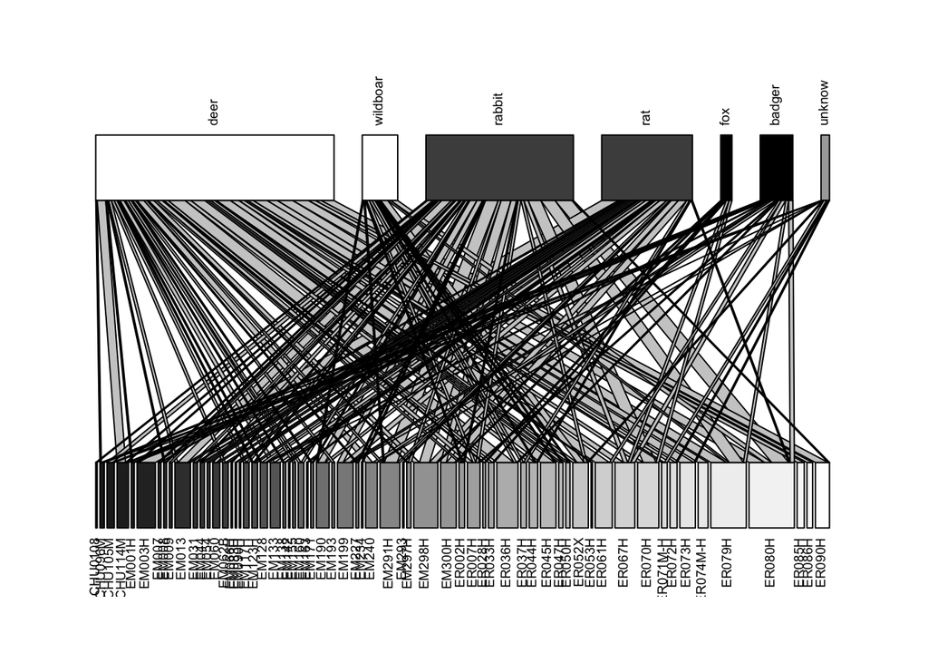

#### **Step 6.1** Calculate indices describing network topography of the general network.

##### **Step 6.1.1** Network measures

- **Network level** Analysis of bipartite webs at the level of the entire network
- *Connectance*
- *Cluster coefficient*
- *Web Assymethry*
- *Nestednes and Wegihted Nestedness:*

```r
networklevel(mart_matas_visits, index = c("connectance","web asymmetry","cluster coefficient","nestedness","weighted nestedness"))
```

```
##            connectance          web asymmetry    cluster coefficient
##              0.3242630             -0.8000000              0.2063492
##             nestedness    weighted nestedness cluster.coefficient.HL
##             32.8063560              0.5884266              0.5141107
## cluster.coefficient.LL
##              0.4240567
```

- *Modularity*

Matasgordas y Martinazo

```
## [1] 0.3578257
```

##### Ploting modules in the networks

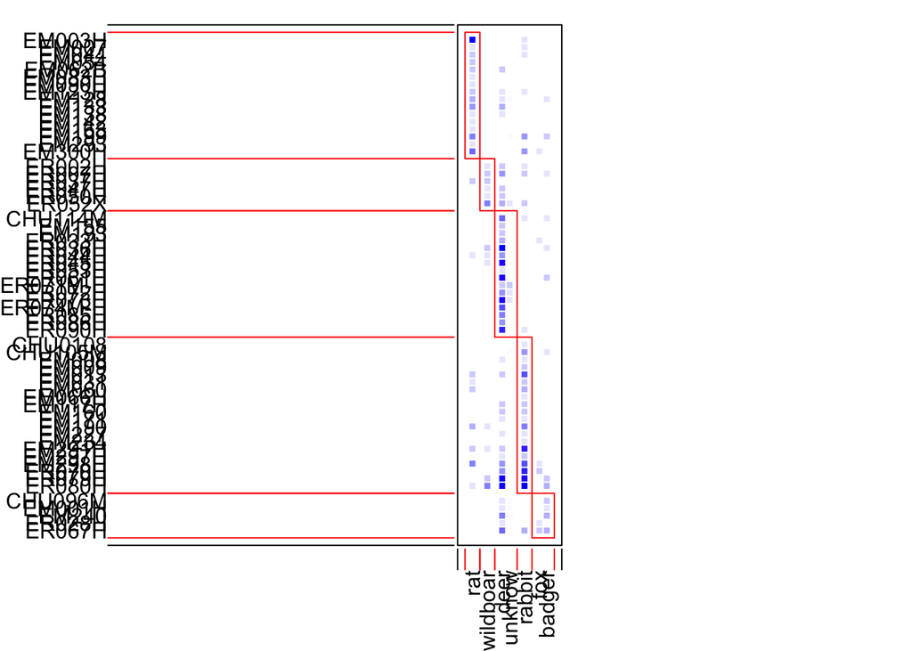

Figure 3.

&nbsp * **Link level.** Interaction variance between nodes. The outcome is a matrix with dependence values. Computes the contribution of each species to the overall nestedness.

```r
linklevel(mart_matas_visits)
```

```
## $`HL dependence`
##                 deer   wildboar      rabbit        rat    fox     badger
## CHU0108  0.000000000 0.00000000 0.009615754 0.00000000 0.0000 0.00000000
## CHU0111  0.000000000 0.00000000 0.000000000 0.00000000 0.0000 0.00000000
## CHU096M  0.005952948 0.00000000 0.000000000 0.00000000 0.0000 0.08695652
## CHU100   0.000000000 0.00000000 0.000000000 0.00000000 0.0000 0.00000000
## CHU105M  0.000000000 0.00000000 0.038463018 0.00000000 0.0000 0.04347826
## CHU114M  0.035717687 0.00000000 0.009615754 0.00000000 0.0000 0.04347826
## EM001H   0.005952948 0.00000000 0.000000000 0.00000000 0.0000 0.04347826
## EM003H   0.000000000 0.00000000 0.009615754 0.18751172 0.0000 0.00000000
## EM007    0.000000000 0.00000000 0.009615754 0.01562598 0.0000 0.00000000
## EM008    0.005952948 0.00000000 0.009615754 0.00000000 0.0000 0.00000000
## EM009    0.000000000 0.00000000 0.019231509 0.00000000 0.0000 0.00000000
## EM013    0.011905896 0.00000000 0.067310281 0.03125195 0.0000 0.00000000
## EM028    0.000000000 0.00000000 0.000000000 0.00000000 0.0000 0.00000000
## EM031    0.000000000 0.00000000 0.019231509 0.01562598 0.0000 0.00000000
## EM044    0.000000000 0.00000000 0.009615754 0.03125195 0.0000 0.00000000
## EM054    0.000000000 0.00000000 0.000000000 0.03125195 0.0000 0.00000000
## EM060    0.000000000 0.00000000 0.028847263 0.03125195 0.0000 0.00000000
## EM062B   0.011905896 0.00000000 0.000000000 0.03125195 0.0000 0.00000000
## EM066H   0.000000000 0.00000000 0.009615754 0.00000000 0.0000 0.00000000
## EM083H   0.000000000 0.00000000 0.000000000 0.01562598 0.0000 0.00000000
## EM090H   0.000000000 0.00000000 0.000000000 0.01562598 0.0000 0.00000000
## EM097H   0.000000000 0.00000000 0.000000000 0.00000000 0.0000 0.00000000
## EM117H   0.011905896 0.00000000 0.019231509 0.00000000 0.0000 0.00000000
## EM123H   0.005952948 0.00000000 0.009615754 0.03125195 0.0000 0.00000000
## EM128    0.005952948 0.00000000 0.000000000 0.04687793 0.0000 0.04347826
## EM133    0.017858844 0.00000000 0.000000000 0.06250391 0.0000 0.00000000
## EM136    0.000000000 0.00000000 0.000000000 0.00000000 0.0000 0.00000000
## EM138    0.005952948 0.00000000 0.000000000 0.01562598 0.0000 0.00000000
## EM142    0.000000000 0.00000000 0.000000000 0.01562598 0.0000 0.00000000
## EM155    0.011905896 0.00000000 0.000000000 0.00000000 0.0000 0.00000000
## EM160    0.011905896 0.00000000 0.019231509 0.00000000 0.0000 0.00000000
## EM163    0.000000000 0.00000000 0.000000000 0.01562598 0.0000 0.00000000
## EM171    0.005952948 0.00000000 0.009615754 0.00000000 0.0000 0.00000000
## EM190    0.000000000 0.03999360 0.048078772 0.04687793 0.0000 0.00000000
## EM193    0.011905896 0.00000000 0.000000000 0.00000000 0.0000 0.00000000
## EM199    0.000000000 0.00000000 0.038463018 0.07812988 0.0000 0.08695652
## EM227    0.005952948 0.00000000 0.009615754 0.00000000 0.0000 0.00000000
## EM234    0.000000000 0.00000000 0.009615754 0.00000000 0.0000 0.00000000
```

[output cut: 305 more lines]

```
## ER050H     86       26      0   0   0      0      0
## ER052X    172       52    128   0   0      0     44
## ER053H     43        0      0   0   0      0      0
## ER061H     86        0      0   0   0     26      0
## ER067H    172        0    128   0  24     52      0
## ER070H    129        0     96   0  18      0      0
## ER071M-H   86        0      0   0   0      0     22
## ER072H     86        0      0   0   0      0     22
## ER073H     86        0      0   0   0      0     22
## ER074M-H   43        0      0   0   0      0      0
## ER079H    172       52    128   0   0     52      0
## ER080H    215       65    160 125   0     65      0
## ER085H     43        0      0   0   0      0      0
## ER086H     43        0      0   0   0      0      0
## ER090H     86        0     64   0   0      0      0
```

##### **Step 6.1.2.**Calculate the topography of the nodes and their relative importance to the network.

- **Relative degree.**
- **Species strength.**
- **Species Specificity.**
- **Node specialisation index.**
- **Effective partners.**

```
spp_lev_mart<-specieslevel(mart_matas_visits)
```

```r
HLspplvlmart<-specieslevel(mart_matas_visits)
HLspplvlmart$`higher level`[,c(2,3,8,10)]
```

```
##          normalised.degree species.strength species.specificity.index
## deer             0.6825397        25.008644                 0.1550816
## wildboar         0.2063492         2.900233                 0.3204469
## rabbit           0.5079365        15.810443                 0.2088534
## rat              0.3968254        14.125118                 0.2445250
## fox              0.0952381         1.175684                 0.4179117
## badger           0.2063492         2.902599                 0.2793267
## unknow           0.1746032         1.077279                 0.4342280
##          node.specialisation.index.NSI
## deer                          1.000000
## wildboar                      1.166667
## rabbit                        1.000000
## rat                           1.000000
## fox                           1.333333
## badger                        1.000000
## unknow                        1.166667
```

```r
LLspplvlmart<-specieslevel(mart_matas_visits)
LLspplvlmart$`lower level`[,c(2,3,7,10,17)]
```

```
##          normalised.degree species.strength species.specificity.index
## CHU0108          0.1428571      0.009615754                 1.0000000
## CHU096M          0.4285714      0.113070760                 0.6590209
## CHU105M          0.4285714      0.102102569                 0.7684763
## CHU114M          0.5714286      0.108972993                 0.7113182
## EM001H           0.4285714      0.069592499                 0.5968550
## EM003H           0.2857143      0.197127474                 0.9134109
## EM007            0.2857143      0.025241731                 0.6454972
## EM008            0.2857143      0.015568702                 0.6454972
## EM009            0.1428571      0.019231509                 1.0000000
## EM013            0.4285714      0.110468130                 0.6188054
## EM031            0.2857143      0.034857486                 0.6938887
## EM044            0.2857143      0.040867708                 0.6938887
## EM054            0.1428571      0.031251953                 1.0000000
## EM060            0.2857143      0.060099217                 0.6633250
## EM062B           0.2857143      0.043157849                 0.6454972
## EM066H           0.1428571      0.009615754                 1.0000000
## EM083H           0.1428571      0.015625977                 1.0000000
## EM090H           0.1428571      0.015625977                 1.0000000
## EM117H           0.2857143      0.031137405                 0.6454972
## EM123H           0.4285714      0.046820656                 0.5204165
## EM128            0.5714286      0.116470429                 0.5687944
## EM133            0.2857143      0.080362750                 0.6546537
## EM138            0.2857143      0.021578924                 0.6454972
## EM142            0.1428571      0.015625977                 1.0000000
## EM155            0.1428571      0.011905896                 1.0000000
## EM160            0.2857143      0.031137405                 0.6454972
## EM163            0.1428571      0.015625977                 1.0000000
## EM171            0.2857143      0.015568702                 0.6454972
## EM190            0.4285714      0.134950303                 0.5809032
## EM193            0.1428571      0.011905896                 1.0000000
## EM199            0.5714286      0.223710713                 0.5079760
## EM227            0.2857143      0.015568702                 0.6454972
## EM234            0.1428571      0.009615754                 1.0000000
## EM240            0.4285714      0.200522103                 0.6469437
## EM291H           0.5714286      0.169693240                 0.6074929
## EM293            0.1428571      0.015625977                 1.0000000
## EM297H           0.2857143      0.025184457                 0.6938887
## EM298H           0.5714286      0.294251956                 0.4479867
## EM300H           0.4285714      0.257218877                 0.5868157
```

[output cut: 73 more lines]

```
## ER050H                        1.290323           1.888128
## ER052X                        1.096774           3.456535
## ER053H                        1.322581           1.000000
## ER061H                        1.290323           1.570034
## ER067H                        1.112903           3.674766
## ER070H                        1.112903           2.528944
## ER071M-H                      1.290323           2.000000
## ER072H                        1.290323           1.648285
## ER073H                        1.290323           1.355201
## ER074M-H                      1.322581           1.000000
## ER079H                        1.096774           3.102768
## ER080H                        1.000000           3.876422
## ER085H                        1.322581           1.000000
## ER086H                        1.322581           1.000000
## ER090H                        1.112903           1.383050
```

[^1]: Notice: Plants colors in gray scale [col.low=c(gray(seq(0.1,1,length=24)))], goes from black (aggregated plants) to white (more isolated), *length* refers to the number of plants in the plot. In High level, different colors in “col.high” means different guilds: white=predators, dark gray=defleshers, black=dispersers and light gray=unknow.